# Pratical machine learning

Tommaso Ancilli

5/18/2021

# Load dataset and the library needed

```r
library(caret)
```

```r
library(ggplot2)
library(rattle)
library(randomForest)
```

Here, you can download the datasets: [training](https://d396qusza40orc.cloudfront.net/predmachlearn/pml-training.csv)

[testing](https://d396qusza40orc.cloudfront.net/predmachlearn/pml-testing.csv)

```r
pml_training<- read.csv("/Users/tommasoancilli/Downloads/pml-training.csv")
pml_testing <- read.csv("/Users/tommasoancilli/Downloads/pml-testing.csv")
```

```r
na_value <- colMeans(is.na(pml_training))
na_value[which(na_value>0.5)]
```

```
##            max_roll_belt           max_picth_belt            min_roll_belt
##                0.9793089                0.9793089                0.9793089
##           min_pitch_belt      amplitude_roll_belt     amplitude_pitch_belt
##                0.9793089                0.9793089                0.9793089
##     var_total_accel_belt            avg_roll_belt         stddev_roll_belt
##                0.9793089                0.9793089                0.9793089
##            var_roll_belt           avg_pitch_belt        stddev_pitch_belt
##                0.9793089                0.9793089                0.9793089
##           var_pitch_belt             avg_yaw_belt          stddev_yaw_belt
##                0.9793089                0.9793089                0.9793089
##             var_yaw_belt            var_accel_arm             avg_roll_arm
##                0.9793089                0.9793089                0.9793089
##          stddev_roll_arm             var_roll_arm            avg_pitch_arm
##                0.9793089                0.9793089                0.9793089
##         stddev_pitch_arm            var_pitch_arm              avg_yaw_arm
##                0.9793089                0.9793089                0.9793089
##           stddev_yaw_arm              var_yaw_arm             max_roll_arm
##                0.9793089                0.9793089                0.9793089
##            max_picth_arm              max_yaw_arm             min_roll_arm
##                0.9793089                0.9793089                0.9793089
##            min_pitch_arm              min_yaw_arm       amplitude_roll_arm
##                0.9793089                0.9793089                0.9793089
##      amplitude_pitch_arm        amplitude_yaw_arm        max_roll_dumbbell
##                0.9793089                0.9793089                0.9793089
##       max_picth_dumbbell        min_roll_dumbbell       min_pitch_dumbbell
##                0.9793089                0.9793089                0.9793089
##  amplitude_roll_dumbbell amplitude_pitch_dumbbell       var_accel_dumbbell
##                0.9793089                0.9793089                0.9793089
##        avg_roll_dumbbell     stddev_roll_dumbbell        var_roll_dumbbell
##                0.9793089                0.9793089                0.9793089
##       avg_pitch_dumbbell    stddev_pitch_dumbbell       var_pitch_dumbbell
##                0.9793089                0.9793089                0.9793089
##         avg_yaw_dumbbell      stddev_yaw_dumbbell         var_yaw_dumbbell
##                0.9793089                0.9793089                0.9793089
##         max_roll_forearm        max_picth_forearm         min_roll_forearm
##                0.9793089                0.9793089                0.9793089
##        min_pitch_forearm   amplitude_roll_forearm  amplitude_pitch_forearm
##                0.9793089                0.9793089                0.9793089
##        var_accel_forearm         avg_roll_forearm      stddev_roll_forearm
##                0.9793089                0.9793089                0.9793089
##         var_roll_forearm        avg_pitch_forearm     stddev_pitch_forearm
##                0.9793089                0.9793089                0.9793089
##        var_pitch_forearm          avg_yaw_forearm       stddev_yaw_forearm
##                0.9793089                0.9793089                0.9793089
##          var_yaw_forearm
##                0.9793089
```

[figure not shown]

```r
na_value <- as.data.frame(na_value)
na_value$name <- names(colMeans(is.na(pml_training)))
ggplot(data=na_value,aes(x=na_value,y=name))+geom_bar(stat='identity')
```

As you can see there are a lot of variables which have a plenty of Null/Na values, hence we must remove these from our data set. Otherwise we will face some difficulty in apply our regression models.

# Data cleaning

I divided the data clining part in 3 subsets.

In this *first one*, following the previous plot, I eliminate every column which has more than 50% of its value as NA. Obiviosly, I apply this function on both data sets

```r
na_value_elimination <- sapply(pml_training,function (x) mean(is.na(x))>0.5)

pml_training <- pml_training[,na_value_elimination==F]
pml_testing <- pml_testing[,na_value_elimination==F]
```

In this *second part*, manually I remove the first seven columns which are character columns, hence they are not usefull for the model.

```r
pml_training <- subset(pml_training,select=-c(1:7))
pml_testing <- subset(pml_testing,select = -c(1:7))
```

In the *last one*, I remove columns which do not give enough information.

```r
index_value <- nearZeroVar(pml_training)

pml_training <- pml_training[,-index_value]
pml_testing <- pml_testing[,-index_value]
```

#Data partition As the course teaches, I divided my initial data set in a training and testing one. Therefore, I am able to conduct some inferential analysis and to validate my machine learning model.

```r
partition_index <- createDataPartition(pml_training$classe,p=0.7,list = F)

training <- pml_training[partition_index,]
testing <- pml_training[-partition_index,]
```

#Model Fitting

To decide which is the best model for our problem I decided to develop several models, and the best I will use for predicting the outcome.

**Random forest model**

```r
mod_rf <- train(classe~.,data=training,method="rf",ntree=100)
Predrf<- predict(mod_rf,testing)
message("Statistics of randon forest model")
```

```
## Statistics of randon forest model
```

```r
confusionMatrix(Predrf,as.factor(testing$classe))
```

```
## Confusion Matrix and Statistics
##
##           Reference
## Prediction    A    B    C    D    E
##          A 1671    6    0    0    0
##          B    2 1130    4    0    1
##          C    0    3 1022   10    2
##          D    0    0    0  953    8
##          E    1    0    0    1 1071
##
## Overall Statistics
##
##                Accuracy : 0.9935
##                  95% CI : (0.9911, 0.9954)
##     No Information Rate : 0.2845
##     P-Value [Acc > NIR] : < 2.2e-16
##
##                   Kappa : 0.9918
##
##  Mcnemar's Test P-Value : NA
##
## Statistics by Class:
##
##                      Class: A Class: B Class: C Class: D Class: E
## Sensitivity            0.9982   0.9921   0.9961   0.9886   0.9898
## Specificity            0.9986   0.9985   0.9969   0.9984   0.9996
## Pos Pred Value         0.9964   0.9938   0.9855   0.9917   0.9981
## Neg Pred Value         0.9993   0.9981   0.9992   0.9978   0.9977
## Prevalence             0.2845   0.1935   0.1743   0.1638   0.1839
## Detection Rate         0.2839   0.1920   0.1737   0.1619   0.1820
## Detection Prevalence   0.2850   0.1932   0.1762   0.1633   0.1823
## Balanced Accuracy      0.9984   0.9953   0.9965   0.9935   0.9947
```

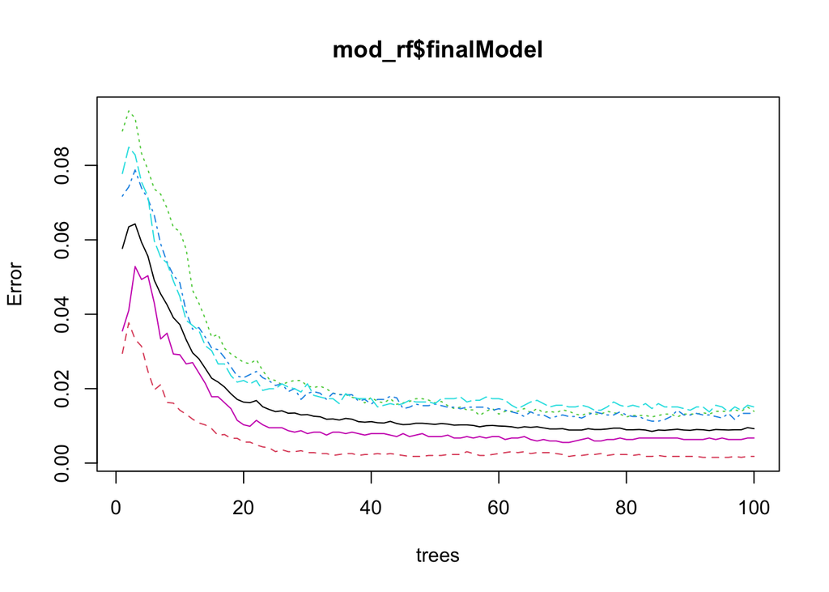

```r
plot(mod_rf$finalModel)
```

**Gradient boosting model**

```r
mod_gbm <- train(classe~.,data=training,method="gbm",verbose=F)
Predgbm <- predict(mod_gbm,testing)
message("Statistics of gbm")
```

```
## Statistics of gbm
```

```r
confusionMatrix(Predgbm,as.factor(testing$classe))
```

```
## Confusion Matrix and Statistics
##
##           Reference
## Prediction    A    B    C    D    E
##          A 1652   40    0    0    2
##          B   10 1068   30    2   10
##          C    9   27  987   39   10
##          D    2    2    9  922   20
##          E    1    2    0    1 1040
##
## Overall Statistics
##
##                Accuracy : 0.9633
##                  95% CI : (0.9582, 0.968)
##     No Information Rate : 0.2845
##     P-Value [Acc > NIR] : < 2.2e-16
##
##                   Kappa : 0.9536
##
##  Mcnemar's Test P-Value : 3.554e-13
##
## Statistics by Class:
##
##                      Class: A Class: B Class: C Class: D Class: E
## Sensitivity            0.9869   0.9377   0.9620   0.9564   0.9612
## Specificity            0.9900   0.9890   0.9825   0.9933   0.9992
## Pos Pred Value         0.9752   0.9536   0.9207   0.9654   0.9962
## Neg Pred Value         0.9948   0.9851   0.9919   0.9915   0.9913
## Prevalence             0.2845   0.1935   0.1743   0.1638   0.1839
## Detection Rate         0.2807   0.1815   0.1677   0.1567   0.1767
## Detection Prevalence   0.2879   0.1903   0.1822   0.1623   0.1774
## Balanced Accuracy      0.9884   0.9634   0.9722   0.9749   0.9802
```

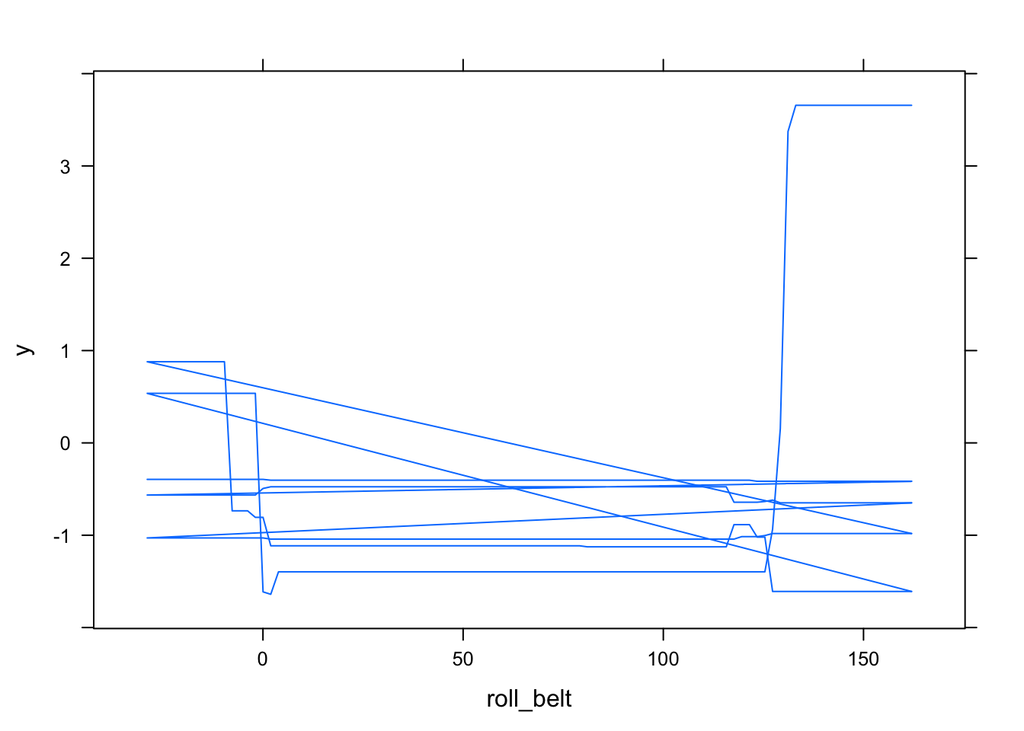

```r
plot(mod_gbm$finalModel)
```

**A tree model with a pre-processing of pca**

```r
fit_pca <- train(classe~.,data=training,method="rpart",preProcess="pca")
PredPCA <- predict(fit_pca,testing)
message("Statistics of r part with a pca")
```

```
## Statistics of r part with a pca
```

```r
confusionMatrix(PredPCA,as.factor(testing$classe))
```

```
## Confusion Matrix and Statistics
##
##           Reference
## Prediction    A    B    C    D    E
##          A 1658 1035 1004  893  727
##          B    0    0    0    0    0
##          C    0    0    0    0    0
##          D    0    0    0    0    0
##          E   16  104   22   71  355
##
## Overall Statistics
##
##                Accuracy : 0.3421
##                  95% CI : (0.3299, 0.3543)
##     No Information Rate : 0.2845
##     P-Value [Acc > NIR] : < 2.2e-16
##
##                   Kappa : 0.0928
##
##  Mcnemar's Test P-Value : NA
##
## Statistics by Class:
##
##                      Class: A Class: B Class: C Class: D Class: E
## Sensitivity            0.9904   0.0000   0.0000   0.0000  0.32810
## Specificity            0.1311   1.0000   1.0000   1.0000  0.95565
## Pos Pred Value         0.3118      NaN      NaN      NaN  0.62500
## Neg Pred Value         0.9718   0.8065   0.8257   0.8362  0.86327
## Prevalence             0.2845   0.1935   0.1743   0.1638  0.18386
## Detection Rate         0.2817   0.0000   0.0000   0.0000  0.06032
## Detection Prevalence   0.9035   0.0000   0.0000   0.0000  0.09652
## Balanced Accuracy      0.5608   0.5000   0.5000   0.5000  0.64187
```

**LDA model**

```r
mod_lda <- train(classe~.,data=training,method="lda",verbose=F)
Predlda<- predict(mod_lda,testing)
message("Statistics of  lda")
```

```
## Statistics of  lda
```

```r
confusionMatrix(Predlda,as.factor(testing$classe))
```

```
## Confusion Matrix and Statistics
##
##           Reference
## Prediction    A    B    C    D    E
##          A 1341  170   90   52   34
##          B   40  718  108   35  176
##          C  147  159  707  130   96
##          D  139   42   95  686   96
##          E    7   50   26   61  680
##
## Overall Statistics
##
##                Accuracy : 0.7021
##                  95% CI : (0.6903, 0.7138)
##     No Information Rate : 0.2845
##     P-Value [Acc > NIR] : < 2.2e-16
##
##                   Kappa : 0.6235
##
##  Mcnemar's Test P-Value : < 2.2e-16
##
## Statistics by Class:
##
##                      Class: A Class: B Class: C Class: D Class: E
## Sensitivity            0.8011   0.6304   0.6891   0.7116   0.6285
## Specificity            0.9178   0.9244   0.8905   0.9244   0.9700
## Pos Pred Value         0.7949   0.6667   0.5706   0.6484   0.8252
## Neg Pred Value         0.9207   0.9124   0.9313   0.9424   0.9206
## Prevalence             0.2845   0.1935   0.1743   0.1638   0.1839
## Detection Rate         0.2279   0.1220   0.1201   0.1166   0.1155
## Detection Prevalence   0.2867   0.1830   0.2105   0.1798   0.1400
## Balanced Accuracy      0.8595   0.7774   0.7898   0.8180   0.7992
```

# Conclusion

As the data show, the best machine learning model is the *RANDOM FOREST* one, so I have used it to predict from the pml_testing data set.

#Final Prediction

```r
predict(mod_rf,pml_testing)
```

```
##  [1] B A B A A E D B A A B C B A E E A B B B
## Levels: A B C D E
```